# Tidy text and preprocessing in R

Jae Yeon Kim

13 November, 2019

The technical part of the material is adapted from [Text Mining with R](https://proquest.safaribooksonline.com/9781491981641) (2017) by Julia Silge and David Robinson and the theoretical part from Foundations of Statistical Natural Language Processing (1999) by Christopher D. Manning and Heinrich Schütze. Silge and Robinson’s book is an accessible introduction to text analysis in R. I like the book a lot since it uses tidyverse framework so you can use the skills you developed earlier in this course to text analysis. Manning and Schütze’s book is still the best theoretical introduction to natural language processing.

**Learning objectives**

```
1. Understanding basic theoretical ideas of natural language processing (NLP)
2. Understanding the steps students need to take to conduct a text analysis
```

This is part of the analysis part of the course. We start from text analysis fundamentals to dictionary-based methods (non-model approach) to topic modeling (unsupervised learning) to classification (supervised learning).

Before digging into technical details, let’s take a step back and think about this question for a movement: “What Is a Language?”

- **Rationalist approach**: Chomsky’s “the poverty of the stimulus” argument -> language acquisition device and universal grammar (language is something hardwired in our brain and has a very specific design.)
- **Empiricist approach**: They also agree that language is part of our brain. But they believe that our brain doesn’t have a very specific design, but has general operational rules like association, pattern recognition, and generalization. It is an old idea that is now re-surging with the new computational methods.

**Statistical NLP** is a child of the empiricist approach. The belief is we can understand the structure of language by specifying an appropriate general language model, and then inducing the values of parameters by applying statistical, pattern recognition, and machine learning methods to a large amount of language use (mostly big texts called a *corpus* – Latin word for “body”).

Language processing is getting the meaning out of the structure of language. Statistical NLP does that by treating language and cognition as **probabilistic** phenomenon. Cognition has some kind of quantitative framework that can handle uncertainty and incomplete information that surround humans in the world. If cognition is probabilistic, then its outcome (language) is also probabilistic. (For this reason, the deeper theoretical understanding of NLP requires some knowledge of probability and information theory.)

This idea is the foundation for everything we do in computational text analysis.

# Setup

```r
# remove all objects
rm(list=ls())

# check working directory
getwd()
```

```
## [1] "C:/Users/Julia/OneDrive/Documents/Berkeley/2019-08_Fall/PS239T_Fall2019/12_text-analysis/02_r-text-analysis"
```

```r
# Unload all packages
library(pacman)
pacman::p_unload(all)
```

```
## The following packages have been unloaded:
## pacman
```

```r
# Add packages
pacman::p_load(
  tidyverse, #ggplot, dplyr, readr, etc.
  tm, #text mining
  tidytext, #text analysis
  quanteda #text analysis examples
)
```

# Corpus

A corpus is a collection of texts (raw strings, often called “documents”) annotated with meta data (e.g., author, date, source)

For this exercise, we play with Martin Luther King Jr’s “I have a dream” speech.

# Tidytext

## Create a corpus

```r
# load MLK speech
MLK <- readLines("http://www.sthda.com/sthda/RDoc/example-files/martin-luther-king-i-have-a-dream-speech.txt")

# look at first 10 cells
MLK[1:10]
```

```
##  [1] ""
##  [2] "And so even though we face the difficulties of today and tomorrow, I still have a dream. It is a dream deeply rooted in the American dream."
##  [3] " "
##  [4] "I have a dream that one day this nation will rise up and live out the true meaning of its creed:"
##  [5] " "
##  [6] "We hold these truths to be self-evident, that all men are created equal."
##  [7] " "
##  [8] "I have a dream that one day on the red hills of Georgia, the sons of former slaves and the sons of former slave owners will be able to sit down together at the table of brotherhood."
##  [9] " "
## [10] "I have a dream that one day even the state of Mississippi, a state sweltering with the heat of injustice, sweltering with the heat of oppression, will be transformed into an oasis of freedom and justice."
```

## Tidy text

- tibble is a class of data frame in the dplyr and tibble packages.
- It’s better than built-in data frame since it does not convert strings to factors.

```r
# tidy text
MLK_df <- data_frame(line = 1:length(MLK), text = MLK)
# see data
MLK_df
```

```
## # A tibble: 46 x 2
##     line text
##    <int> <chr>
##  1     1 ""
##  2     2 And so even though we face the difficulties of today and tomorrow~
##  3     3 " "
##  4     4 I have a dream that one day this nation will rise up and live out~
##  5     5 " "
##  6     6 We hold these truths to be self-evident, that all men are created~
##  7     7 " "
##  8     8 I have a dream that one day on the red hills of Georgia, the sons~
##  9     9 " "
## 10    10 I have a dream that one day even the state of Mississippi, a stat~
## # ... with 36 more rows
```

```r
# see class
class(MLK_df)
```

```
## [1] "tbl_df"     "tbl"        "data.frame"
```

# Preprocessing

- In the end, you need to figure out how to represent text data in a numerical way.
- And how to reduce dimensions of such text data by
  - 1. tokenizing and using n-grams,
  - 2. removing noise (e.g., html tags), and
  - 3. [normalizing](https://en.wikipedia.org/wiki/Text_normalization) (e.g., stop words, [stemming and lemmatization](https://nlp.stanford.edu/IR-book/html/htmledition/stemming-and-lemmatization-1.html)).
- In this unit, we focus on 1) and 3). For noise removing, you might need to learn how to do string manipulations by using [regular expressions](https://www.regular-expressions.info/) in R.

## Tokenizing

[Tokenizing](https://nlp.stanford.edu/IR-book/html/htmledition/tokenization-1.html) splits longer strings into smaller pieces (called ‘tokens’).

From now on, we use the US presidential inaugural address texts from quanteda package to have experience with complicated data.

- For unnest_tokens, word is a token output and text is a text input.
- The function also strips punctuation, and converts the tokens to lower case. (Check to_lower argument.). This is nice because we want words not uninteresting characters like punctuation.
- Also, note that tokenizing is language specific. We only deal with English text data here.

```r
# load data
inaug <- tidy(data_corpus_inaugural)

head(inaug)
```

```
## # A tibble: 6 x 4
##   text                                             Year President FirstName
##   <chr>                                           <dbl> <chr>     <chr>
## 1 "Fellow-Citizens of the Senate and of the Hous~  1789 Washingt~ George
## 2 "Fellow citizens, I am again called upon by th~  1793 Washingt~ George
## 3 "When it was first perceived, in early times, ~  1797 Adams     John
## 4 "Friends and Fellow Citizens:\n\nCalled upon t~  1801 Jefferson Thomas
## 5 "Proceeding, fellow citizens, to that qualific~  1805 Jefferson Thomas
## 6 "Unwilling to depart from examples of the most~  1809 Madison   James
```

```r
# Tokenize data
inaug %>%
  group_by(President) %>%
  unnest_tokens(word, text)
```

```
## # A tibble: 135,562 x 4
## # Groups:   President [35]
##     Year President  FirstName word
##    <dbl> <chr>      <chr>     <chr>
##  1  1789 Washington George    fellow
##  2  1789 Washington George    citizens
##  3  1789 Washington George    of
##  4  1789 Washington George    the
##  5  1789 Washington George    senate
##  6  1789 Washington George    and
##  7  1789 Washington George    of
##  8  1789 Washington George    the
##  9  1789 Washington George    house
## 10  1789 Washington George    of
## # ... with 135,552 more rows
```

```r
# Note the structure of this data
```

### CHALLENGE 1: Tokenize MLK speech by line

```r
MLK_df %>%
  # add your code here
```

## Using N-grmas

N-gram is a consecutive sequence of words.

```r
# no filtered
inaug %>%
  filter(Year > 1945) %>%
  group_by(President) %>%
  unnest_tokens(bigram, text, token = "ngrams", n = 2) %>%
  count(bigram, sort = TRUE)
```

```
## # A tibble: 27,919 x 3
## # Groups:   President [11]
##    President  bigram      n
##    <chr>      <chr>   <int>
##  1 Eisenhower in the     33
##  2 Bush       of our     32
##  3 Bush       we will    31
##  4 Nixon      of the     31
##  5 Bush       of the     30
##  6 Obama      of our     30
##  7 Eisenhower of the     29
##  8 Bush       and the    27
##  9 Eisenhower of our     27
## 10 Nixon      in the     27
## # ... with 27,909 more rows
```

```r
# filtered
inaug_filtered <- inaug %>%
  filter(Year > 1945) %>%
  group_by(President) %>%
  unnest_tokens(bigram, text, token = "ngrams", n = 2) %>%
  separate(bigram, c("word1", "word2"), sep = " ") %>%
  filter(!word1 %in% stop_words$word) %>%
  filter(!word2 %in% stop_words$word)

## count
inaug_filtered %>%
  unite(bigram, word1, word2, sep = " ") %>%
  count(bigram, sort = TRUE)
```

```
## # A tibble: 2,797 x 3
## # Groups:   President [11]
##    President bigram                 n
##    <chr>     <chr>              <int>
##  1 Reagan    federal government     7
##  2 Clinton   fellow americans       6
##  3 Clinton   fellow citizens        6
##  4 Bush      god bless              5
##  5 Truman    free nations           5
##  6 Truman    united nations         5
##  7 Bush      fellow citizens        4
##  8 Clinton   21st century           4
##  9 Reagan    fellow citizens        4
## 10 Reagan    god bless              4
## # ... with 2,787 more rows
```

```r
## count with filter
inaug_filtered %>%
  filter(word2 == "government") %>%
  count(President, word2, sort = TRUE)
```

```
## # A tibble: 4 x 3
## # Groups:   President [4]
##   President word2          n
##   <chr>     <chr>      <int>
## 1 Reagan    government    13
## 2 Nixon     government     3
## 3 Clinton   government     2
## 4 Bush      government     1
```

## Normalizing

### Stop words

- Remove common words (something like “the”) not useful for the analysis
- These words are technically called [stop words](https://en.wikipedia.org/wiki/Stop_words) in natural language processing.
- Also, remember that removing stop words is not always a good idea. Think about “to be” or “not to be”. If you delete “not”, there’s no difference between the two words.
- If you want to cut out (assumed unnecessary) parts of the text, you can try either [stemming](https://en.wikipedia.org/wiki/Stemming) (no “ed”, “ing”, or “ly” in the end) or [lemminization](https://en.wikipedia.org/wiki/Lemmatisation) (better -> goo).

```r
MLK_df %>%
  unnest_tokens(word, text) %>%
  count(word, sort = TRUE)
```

```
## # A tibble: 214 x 2
##    word        n
##    <chr>   <int>
##  1 of         34
##  2 the        31
##  3 and        26
##  4 be         20
##  5 will       17
##  6 to         16
##  7 a          15
##  8 freedom    13
##  9 from       12
## 10 ring       12
## # ... with 204 more rows
```

```r
# load stopwords dataset
data(stopwords)
# apply stopwords
MLK_df %>%
  unnest_tokens(word, text) %>%
  anti_join(stop_words) %>%
  count(word, sort = TRUE)
```

```
## # A tibble: 135 x 2
##    word         n
##    <chr>    <int>
##  1 freedom     13
##  2 ring        12
##  3 day         11
##  4 dream       11
##  5 faith        4
##  6 free         4
##  7 mountain     4
##  8 nation       4
##  9 black        3
## 10 children     3
## # ... with 125 more rows
```

- Now, visualize the results.

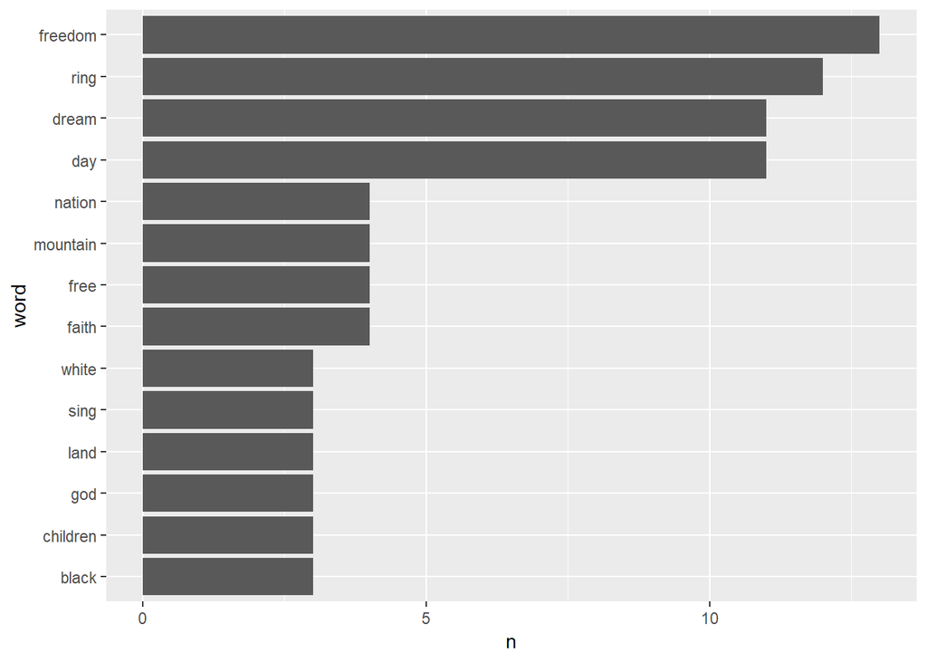

```r
MLK_df %>%
  unnest_tokens(word, text) %>%
  anti_join(stop_words) %>%
  count(word, sort = TRUE) %>%
  filter(n > 2) %>%
  mutate(word = reorder(word, n)) %>%
  ggplot(aes(x = word,  y = n)) +
  geom_col() +
  coord_flip()
```

### tf-idf

- TF indicates a term frequency.
- IDF indicates a term’s inverse document frequency.
- if-idf multiples the term frequency and the inverse document frequency.
- IDF decreases the weight for common words and increases the weight for less common words.

We are going to see how IDF works with an actual example.

```r
# words
inaug_words <- inaug %>%
  filter(Year > 1945) %>%
  unnest_tokens(word, text) %>%
  count(President, word, sort = TRUE) %>%
  ungroup() # to return to nongrouped data

# total words
inaug_total <- inaug_words %>%
  group_by(President) %>%
  summarize(total = sum(n))

# merge
inaug_words <- left_join(inaug_words, inaug_total)
inaug_words
```

```
## # A tibble: 10,258 x 4
##    President  word      n total
##    <chr>      <chr> <int> <int>
##  1 Bush       the     316  5976
##  2 Bush       and     288  5976
##  3 Eisenhower the     285  4118
##  4 Reagan     the     252  5007
##  5 Obama      the     239  4505
##  6 Eisenhower of      238  4118
##  7 Bush       of      235  5976
##  8 Clinton    the     222  3758
##  9 Nixon      the     219  3929
## 10 Reagan     and     202  5007
## # ... with 10,248 more rows
```

Note that the plot below proves Zipf’s law: the frequency that a word appears is inversely proportional to its rank. As we learn later, this insight is key to the understanding of how topic modeling works. In most cases, we need only a few number of topics because on a few words will have lots of examples.

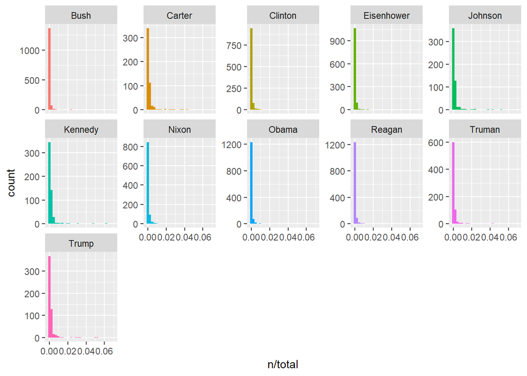

```r
# plot the distribution of n/total
ggplot(data = inaug_words, aes(n/total, fill = President)) +
  geom_histogram(show.legend = FALSE) +
  facet_wrap(~President, ncol = 5, scales = "free_y")
```

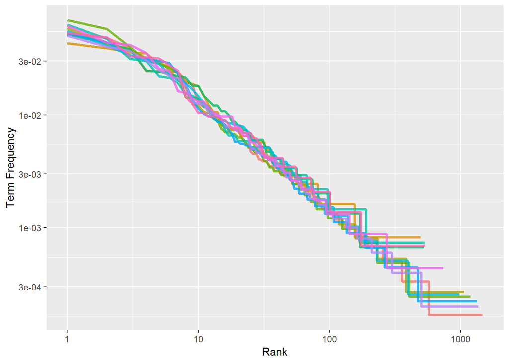

```r
inaug_words %>%
  group_by(President) %>%
  mutate(rank = row_number(),
         term_frequency = n/total) %>%
  ggplot(aes(x = rank, y = term_frequency, color = President)) +
    geom_line(size = 1.1, alpha = 0.8, show.legend = FALSE) +
    scale_x_log10() +
    scale_y_log10() +
    labs(x = "Rank",
         y = "Term Frequency")
```

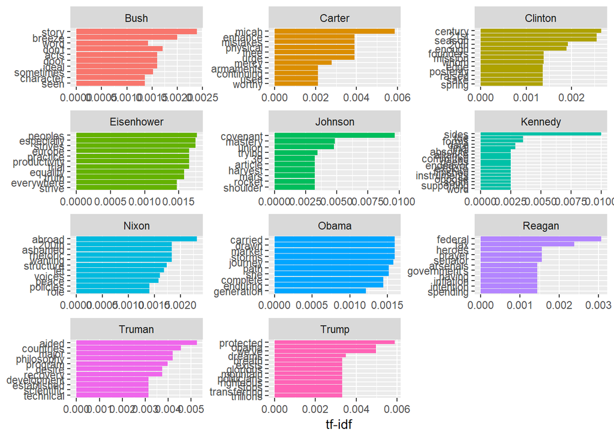

```r
# tf_idf
inaug_words <- inaug_words %>%
  bind_tf_idf(word, President, n)

# visualize
inaug_words %>%
  arrange(desc(tf_idf)) %>%
  mutate(word = factor(word, levels = rev(unique(word)))) %>%
  group_by(President) %>%
  top_n(10) %>%
  ungroup %>%
  ggplot(aes(reorder(word, tf_idf), tf_idf, fill = President)) +
    geom_col(show.legend = FALSE) +
    labs(x = NULL, y = "tf-idf") +
    facet_wrap(~President, ncol = 3, scales = "free") +
    coord_flip()
```